# S9 Presentación

31 Agosto, 2023

# 1 Tema: “Los hábitos alimenticios y su correlación con el rendimiento académico en estudiantes universitarios de UTEC, Barranco-Lima-Perú 2023”

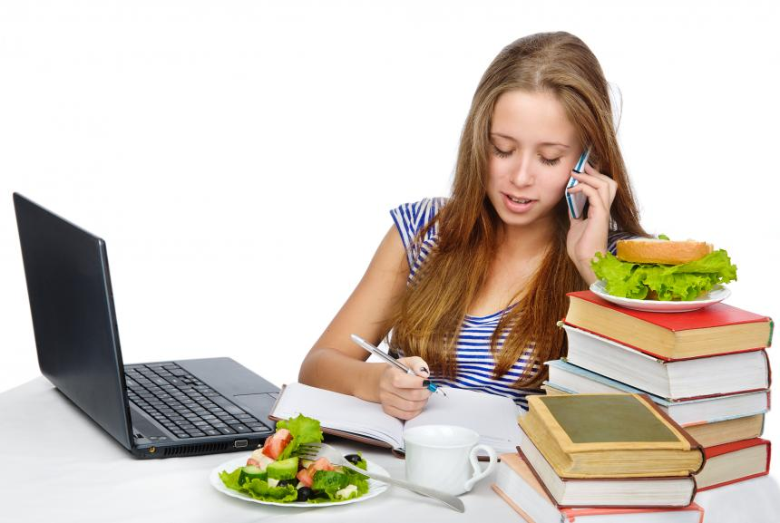

# 2 Introducción

En el ámbito académico, el rendimiento estudiantil es un factor clave para evaluar el éxito educativo. Diversos estudios han demostrado que los hábitos alimenticios de los estudiantes pueden influir significativamente en su desempeño académico. En este contexto, el presente estudio tiene como objetivo general determinar la relación entre los hábitos alimenticios y el rendimiento académico de los estudiantes universitarios de UTEC.

## 2.1 Objetivos específicos

- Identificar los hábitos de alimentación que tienen los estudiantes de UTEC.
- Determinar la posible relación entre el índice de Masa Corporal (IMC) y el rendimiento académico de los estudiantes de UTEC.
- Identificar la frecuencia de consumo de ciertos nutrientes (proteínas,productos lácteos, frutas, verduras, grasas, carbohidratos).

## 2.2 Relevancia

La elección de este tema es relevante debido a la creciente preocupación por la calidad de la alimentación de los jóvenes y su impacto en su desarrollo académico. La etapa universitaria es un momento de transición en la vida de los estudiantes, donde suelen experimentar cambios significativos en su estilo de vida y en sus rutinas alimenticias. Estos cambios pueden influir tanto en su salud física como en su capacidad de concentración, memoria y rendimiento en general.}

## 2.3 Planificación

Instalamos las librerías para garantizar una correcta ejecución del proyecto:

```r
library(dplyr)
library(ggplot2)
library(readr)
library(corrplot)
library(fitdistrplus)
library(plotrix)
library(DescTools)
library(rlg)
library(magick)
```

# 3 Base de datos

## 3.1 Recolección de datos

**Proceso de recolección de datos :** La recolección de datos se realizó utilizando el tipo de muestreo no probabilístico por conveniencia. Para ello se hizo uso de un cuestionario con preguntas que nos ayuden en nuestra investigación.

Las estrategias que se utilizaron para poder llegar a las observaciones requeridas para nuestro estudio fue entrevistar a los alumnos de la universidad de UTEC que se encontraban caminando fuera del horario de clases en los pasillos de la universidad. Además se realizó una difusión del google forms en los grupos de WhatsApp, Telegram y Discord. Finalmente se logró recolectar 174 observaciones.

## 3.2 Población, muestra y muestreo

**RStudio :** Cargamos los datos de nuestro estudio en un data frame inicial llamado DF:

Renombramos a las variables a nombres de una sola palabra para facilitar la lectura y su manejo en R, renombrando al data frame como DF1:

## 3.3 Variables

**Tabla - Tipos de Variables**

| Variables | Tipo | Restricción |
| --- | --- | --- |
| Edad | Numérica → Discreta | Número entero positivo mayor a 15 |
| Género | Categórica → Nominal | Estando las alternativa hombre,mujer,prefiere no decirlo |
| Carrera | Categórica → Nominal | No numérico |
| Ciclo | Categórica → Ordinal | Desplegable para elegir entre el 1 hasta el 10 |
| Peso | Numérica → Continua | Número decimal positivo en Kg entre los números 10 y 150 |
| Estatura | Numérica → Continua | Número decimal en cm entre 40 y 220 |
| Actividad_física | Numérica → Discreta | Número entero no negativo en horas entre 0 y 20 |
| Comidas_Rápidas | Numérica → Discreta | Número entero positivo |
| Hora_Almuerzo | Categórica → Ordinal | Alternativas desde las 12:00 hasta 4:00 |
| Tiempo_almuerzo | Numérica → Discreta | Número entero positivo en minutos |
| Tipo_alimentación | Categórica → Nominal | Alternativas de la procedencia de su comida |
| Preferencia | Categórica → Nominal | Alternativas sobre la causa de la pregunta anterior |
| Mayor_Consumo | Categórica → Nominal | Alternativas sobre los tipos de alimentos |
| Agua | Numérica → Discreta | Número entero positivo en Litros desde 0 a 3 |
| Alimento_Univer- sitario | Categórica → Nominal | No numérico y sea binario (Sí y No) |
| Gastos_comidas_ nosaludables | Numérica → Continua | Número entero no negativo |
| Promedio | Numérica → Continua | Número entero no negativo |
| Rendimiento_aca- démico | Numérica → Discreta | Número entero no negativo |
| Alimentación_Ren- dimiento | Numérica → Continua | Número entero no negativo |

## 3.4 Limpieza de la base de datos

Debido a que las dos primeras variables(‘Marca temporal’ y ‘Puntuación’) de la base de datos no las utilizaremos, decidimos eliminarlas para que no haya ningún error o datos faltantes.

```r
DF1 <- DF1[, -2]
DF1 <- DF1[, -1]
```

En nuestros datos recolectados no existe los datos faltantes (NA); por tal motivo, no se realizará una limpieza de NA, ya que se colocaron como obligatorias todas las preguntas del Google Forms.

Se utilizó el comando `summary` para identificar los datos atípicos

```r
summary(DF1)
```

[output not shown]

Utilizando la información proporcionada por el comando `summary`, observamos que los datos atípicos que se encuentran en nuestra base de datos y notamos que existen algunos que pueden afectar en nuestro análisis estadístico.

### 3.4.1 Variable Gastos_comidas_nosaludables

- En esta variable eliminaremos la observación 91 porque esta contiene un dato atípico(`200`) en la variable Gastos_comidas_nosaludables; decidimos borrar este dato ya que puede afectar negativamente al análisis estadístico creando un sesgo.Aparte de que no hay personas suficientes con la misma o que se acerquen a ese valor.

```r
DF1<-subset(DF1, DF1$Gastos_comidas_nosaludables<180)
```

### 3.4.2 Variable Género

```r
table(DF1$Gènero)
```

[output not shown]

- Después de analizar la variable género mediante un `table`, eliminamos las observaciones **17**, **26** y **162** ya que solo vamos a utilizar los géneros masculino y femenino, debido a que tienen la misma proporción de observaciones. En cambio las respuestas “Prefiero no decirlo” de la variable género no son representativos en el estudio de nuestra investigación.

```r
DF1 <- DF1[-c(17,26,162),]
```

# 4 Descriptores gráficos y numéricos

Creamos esta variable ya que la relacionaremos con algunas variables y asi determinar nuestros objetivos

También crearemos algunas funciones que nos ayudaran a entender más cada descriptor con su respectiva variable

```r
r <- function(n){
  round(n, 2)
}
cv <- function(x){
         return(sd(x,na.rm = TRUE)/mean(x, na.rm = TRUE))
}

Moda <- function(x) {
  return (table(x)[which.max(table(x))])
}
```

## 4.1 Descriptores Gráficos univariados para variables categóricas

###Análisis de la variable Alimentación_Rendimiento

Para ello emplearemos una tabla de frecuencias relativas

```r
fi= table(DF1$Alimentación_Rendimiento)
pi=(r(prop.table(fi)*100))
cbind(fi,pi)
```

[output not shown]

```r
barplot(sort(table(DF1$"Alimentación_Rendimiento")/nrow(DF1),decreasing=TRUE), col = "Lightblue", main = "Gráfico 1
        Alimentación_Rendimiento UTEC",
        xlab = "Nivel de satisfacción",col.main = "Black", ylab = "Frecuencia relativa", border = "Black", cex.names = 0.9)
```

[output not shown]

Del gráfico 1, se observa que el 87.65% de los estudiantes encuestados de UTEC consideran que su alimentación **Sí** afecta a su rendimiento académico y el 12.35% consideran que su alimentación **No** afecta en su rendimiento académico.

###Análisis de la variable Mayor_Consumo

- Las proteínas son necesarias para la síntesis de enzimas, hormonas y neurotransmisores, que son fundamentales para el funcionamiento adecuado del cerebro, al consumir suficientes proteínas, los estudiantes pueden mantener la energía y la concentración durante el día, lo que puede ser especialmente beneficioso durante las largas horas de estudio y las demandas cognitivas asociadas con la vida universitaria.
- Los carbohidratos, por su parte, son la principal fuente de energía para el cuerpo. Proporcionan glucosa, que es utilizada por el cerebro como combustible para el pensamiento y la concentración.Al elegir carbohidratos complejos, como granos enteros, frutas y verduras, los estudiantes pueden obtener nutrientes adicionales, fibra y una liberación de energía más constante a lo largo del día.

Según los especialistas(Viva mi salud, 2020).

### 4.1.2 Análisis sobre la variable Hora_Almuerzo

Según la Dra. Montejo el horario ideal para el almuerzo debe ser entre la 1 pm y 3 pm(Dra. Montejo, s.f.,como se citó en Rojas, 2022)

- Bajos niveles de energia, fatiga y dificultad por concertarse
- No tener un funcionamiento cognitivo optimo en sus clases
- Afectar en su estabilidad emocional y su salud en general

## 4.2 Descriptores gráficos y numéricos univariados para variables numéricas

### 4.2.3 Análisis sobre la variable Gastos_comidas_nosaludable

Analizaremos la siguiente variable numérica continua en un histograma

```r
X <- DF1$Gastos_comidas_nosaludables
media <- mean(X, na.rm = T)
mediana <- median(X, na.rm = T)
```

```r
hist(X, breaks = 30, las = 2, xlim = c(0, 100), ylim = c(0, 35), main = "Gráfico 8
     Gastos de comidas no saludables",
     xlab = "Gastos de comida no saludables", ylab = "Frecuencia", sub = "Sesgo hacia la Derecha")
# Comandos de anotación
abline(v = media, col = "Red", lwd = 2)
abline(v = mediana, col = "Blue", lwd = 2)

legend(33, 20, legend = c("mean", "median"), col = c("Red", "Blue"), lwd = 2)
```

[output not shown]

Observamos que los estudiantes no gastan mucho dinero en el consumo de cómida rápida, teniendo un habito alimenticio saludable, sin embargo hay algunos alumnos que si tienen un gran gasto hacia la comida rápida.

## 4.3 Análisis del IMC

Existe un teorema en probabilidades que menciona que, si una variable presenta un “comportamiento normal” con una distribución simétrica alrededor de la media (curva acampanada) y con datos bien portados (sd no demasiado grande), se cumple lo siguiente:

- La $media \pm 1*sd$ cubre aproximadamente el 68% de los datos
- La $media \pm 2*sd$ cubre aproximadamente el 95% de los datos
- La $media \pm 3*sd$ cubre aproximadamente el 99.7% de los datos

```r
X <- DF1$IMC
media <- mean(X)
desviacion <- sd(X)
```

```r
hist(X, breaks = 10, las = 2, xlim = c(10, 40), main = "Gráfico 9
     IMC",
     xlab = "", ylab = "", sub = "Comportamiento normal leve")
# Media
abline(v = media, col = "Red", lwd = 2)
# 1 sd
abline(v = c(media - desviacion, media + desviacion), col = "Chocolate", lty = 4, lwd = 2)
# 2 sd
abline(v = c(media - 2*desviacion, media + 2*desviacion), col = "Chocolate", lty = 2, lwd = 2)
# 3 sd
abline(v = c(media - 3*desviacion, media + 3*desviacion), col = "Chocolate", lty = 3, lwd = 2)

# Legenda
legend(35, 40, legend = c("mean", "1 sd", "2 sd", "3 sd"), col = c("Red", "Chocolate", "Chocolate", "Chocolate"), lty = c(1, 4, 2, 3), lwd = 2)
```

[output not shown]

En la gráfica 9 se observa que la distribución de los datos de la variable IMC, si están respetando el recorrido de las desviaciones estándar entre 68%, 95% y 99.7%. Por otro lado, se observa que alrededor de la media no hay una distribución simétrica, por lo que se concluye que la variable IMC tiene un comporotamiento normal leve.

### 4.3.1 Medidas de tendencia central:

```r
boxplot(DF1$IMC, main = "Gráfico 10
        Boxplot - IMC",
        ylab = "IMC", col="pink")
```

[output not shown]

No utilizaremos el descriptor numerico “promedio” porque como vemos en el boxplot el IMC presenta datos atipicos por lo tanto para estos casos el descriptor numerico correcto para utilizar es la mediana.

### 4.3.2 Mediana (median)

```r
r(median(DF1$IMC))
```

[output not shown]

El 50% del IMC toma valores máximos como 22.67. Cabe resaltar que estamos trabajando con una variable cuantitativa continua por lo cual en estadística no es recomendable usar la moda.

### 4.3.3 Medidas de Posición

Cuartiles: Q1. Q2=Me y Q3 Deciles: D1, D2, …, D9 Percentiles: P1, P2, …P30, …P54, ….P99

###P10

```r
quantile(DF1$IMC,0.10)
```

[output not shown]

Esto quiere decir que el 10% de los datos obtenidos del IMC con menores valores son como máximo 19.43.

###P85

```r
quantile(DF1$IMC,0.85)
```

[output not shown]

El 15% de los datos obtenidos del IMC son como mínimo un valor de 26.49.

### 4.3.4 Medidas de dispersión

```r
cv(DF1$IMC)
```

[output not shown]

cv: coeficiente de variación

Como el coeficiente de variación es 0.1383878 para la variable IMC, significa que la variabilidad de los valores de IMC es relativamente baja en comparación con su media. Esto indica que los valores de IMC tienden a estar cercanos a su media con una variabilidad promedio del 13.84%.

### 4.3.5 Medidas de Forma

Coeficiente asimetría, usando la formula Fisher:

```r
Skew(DF1$IMC)
```

[output not shown]

## 4.4 Análisis sobre la variable Tiempo_Almuerzo

# 5 Descriptores gráficos y numéricos bivariados

## 5.1 Actividad física vs, Género

### 5.1.1 IMC vs, Género

```r
iqr_IMC <- aggregate(DF1$IMC, by = list(DF1$Gènero), FUN = IQR)
colnames(iqr_IMC) <- c("Género", "IQR_IMC")
iqr_IMC
```

[output not shown]

El IQR (Rango Intercuartil) es una medida de dispersión que indica la amplitud de los valores de IMC en el conjunto de datos analizado. En este caso, se encontró que el IQR de 5.08 para los casos Masculinos y 3.84 para los casos Femeninos. Un IQR mayor indica una mayor variabilidad de los valores de IMC, mientras que un IQR menor indica una menor variabilidad. La diferencia entre los IQR de los casos Masculinos y Femeninos sugiere que los valores de IMC en los casos Masculinos son más variables en comparación con los casos Femeninos en este conjunto de datos.

### 5.1.2 Analisis de Promedio e IMC

Al dibujar las medias aritméticas de las variables y formar cuadrantes, si los datos de una distribución están posicionados en cuadrantes opuestos diagonalmente, podemos afirmar que están *relacionados de manera positiva/ascendente o negativa/descendente*

#COEFICIENTE DE CORRELACIÓN

Sabemos que:

## 5.2 Regresión Lineal

# 6 Análisis multivariado

## 6.1 Diagrama de dispersión por colores

*Numérica - Numérica - Categórica*

## 6.2 Matriz de correlación

```r
#png("grafico.png", width = 800, height = 600)

DFCORR <- dplyr::select(DF1, "Edad", "Peso", "Estatura", "Actividad_Física", "Comidas_Rápidas", "Tiempo_Almuerzo", "Gastos_comidas_nosaludables", "Promedio", "IMC")
corrplot::corrplot(cor(DFCORR), tl.cex = 0.6, tl.srt = 45, tl.col = "black" , main="Gráfico 18- de correlación")
#dev.off()
```

[output not shown]

Del gráfico anterior podemos llegar a las siguientes conclusiones:

1.- Existe una buena relación entre la variable *Estatura* y *Peso* esto quiere decir que presentan aproximadamente una correlación positiva. Lo cual lo podemos comprobar a continuación:

```r
E <- DF1$Estatura/100
P <- DF1$Peso
```

```r
regresión2 <- lm(P ~ E)
```

```r
plot(P ~ E, las = 1, main="Gráfica 19
     Regresión lineal entre Estatura y Peso",
     xlab = "Estatura", ylab = "Peso",pch = 20,col = rgb(0, 0, 0, 0.2))

abline(regresión2, col = "orange", lwd = 2)
```

[output not shown]

```r
summary(regresión2)
```

[output not shown]

$$f(x) = 84.64x - 76.62$$
2.- Existe aparentemente una relación negativa entre el *IMC* y la *actividad fisica*. Una posible explicación vendría a ser que mientras una persona realice más actividad física su nivel de IMC disminuiría. Esto debido a que la actividad física ayuda a quemar calorías y mantener un equilibrio energético saludable. Cuando se combina con una dieta adecuada, puede ayudar a controlar el peso corporal y reducir el IMC 3.- Podemos visualizar una relación positiva entre el *IMC* y el *Peso*, esto quiere decir que a medida que aumenta el peso, también tiende a aumentar el Índice de Masa Corporal (IMC). Dado que el peso es el numerador en la fórmula del IMC, un aumento en el peso resultará en un aumento en el IMC, siempre y cuando la estatura se mantenga constante.

## 6.3 GRÁFICO 3D

(IMC, Peso, Estatura, Género)

```r
colores <- ifelse(DF1$Gènero == "Masculino", "blue", "pink")
colores_numericos <- ifelse(colores == "blue", 1,2)

plot3d(DF1$Estatura, DF1$Peso, DF1$IMC, col = colores, type = "s", radius = 1)
play3d(spin3d(axis = c(0, 0, 1), rpm = 2), duration = 100)
```

[output not shown]

# 7 Bibliografía

Viva mi salud.(6 octubre, 2020). *6 alimentos para mejorar la memoria y el aprendizaje*. Recuperado de: https://www.vivamisalud.com/alimentos-memoria-aprendizaje/

Rojas, G. (2022, abril 18). *Consejos para alimentarse correctamente en la etapa universitaria. Universidad Científica del Sur*. Recuperado de: https://100.cientifica.edu.pe/consejos-para-alimentarse-correctamente-en-la-etapa-universitaria/

Centers for Disease Control and Prevention. (2021, 30 agosto).*Cómo evaluar su peso*. https://www.cdc.gov/healthyweight/spanish/assessing/index.html#:~:text=Si%20su%20IMC%20es%20entre,dentro%20del%20rango%20de%20obesidad

Ibarra Mora, J., Hernández Mosqueira, C. M., & Ventura-Vall-Llovera, C. (2019). *Hábitos alimentarios y rendimiento académico en escolares adolescentes de Chile*. Revista española de nutrición humana y dietética, 23(4), 292–301. Recuperado de: https://doi.org/10.14306/renhyd.23.4.804

Centro medico en valencia.(2022, marzo 16).*Cómo influye la alimentación en el rendimiento académico* https://centromedicomedcare.com/blog/como-influye-la-alimentacion-en-el-rendimiento-academico/